# Chronister_08.Rmd

Andrew Chronister"

06 January 2019

###Load the Libraries

```r
library(tidyverse)
library(lubridate)
```

### Part 1: Play date

#setting the variables/values

```r
birth_date <- "08/23/1968"

# Elizabeth Garret Anderson was the first female physician
anderson <- "9 June 1836"

# Mary Anning discovered the first complete Plesiosaur fossil,
# and other important Jurassic fossils
anning <-  "1799/05/21"

# Alice Augusta Ball was a chemist who developed the
# first injectable treatment for leprosy.
ball <- "July 24, 1892"

# Sylvia Earle was the first chieft scientist at NOAA
earle <- "August, 30 (1935)"

# Rosalind Franklin used x-ray diffraction to
# discover DNA structure. Watson and Crick claimed credit.
franklin <- "25th of July, 1920"

# Ester Lederberg was the first to discover that viruses
# infect bacteria. Led to discovery of lambda bacteriophage
lederberg <- "December 18, 1922"

# Barbara McClintock discovered transposable elements (jumping genes),
# and developed staining techniques to study chromosomes
mcclintock <- "16061902"

# Martin Luther King's birthday is coming up. Let's remember a dream
mlk_birth <- "1/15/29"
mlk_dream <- "1963 August 08"
```

#1. Convert to POSIXct format using lubridate functions.

```r
chronister <- mdy(birth_date)
anderson <- dmy(anderson)
anning <- ymd(anning)
ball <- mdy(ball)
earle <- mdy(earle)
franklin <- dmy(franklin)
lederberg <- mdy(lederberg)
mcclintock <- dmy(mcclintock)
mlk_birth <- mdy(mlk_birth)
mlk_dream <- ymd(mlk_dream)
chronister
```

```
[1] "1968-08-23"
```

```r
anderson
```

```
[1] "1836-06-09"
```

```r
anning
```

```
[1] "1799-05-21"
```

```r
ball
```

```
[1] "1892-07-24"
```

```r
earle
```

```
[1] "1935-08-30"
```

```r
franklin
```

```
[1] "1920-07-25"
```

```r
lederberg
```

```
[1] "1922-12-18"
```

```r
mcclintock
```

```
[1] "1902-06-16"
```

```r
mlk_birth
```

```
[1] "2029-01-15"
```

```r
mlk_dream
```

```
[1] "1963-08-08"
```

#2. Check the dates to make sure they are correct.  
#All the dates appear to be good, except MLK’s birthday, which shows up as 2029 because of the 1968 rule.I believe I can fix it.

```r
mlk_birth <- update(mlk_birth, year = 1929)
mlk_birth
```

```
[1] "1929-01-15"
```

#That looks more like it. The mlk_birth variable has been updated to reflect the correct birth year. Good thing I’m not 8 months older or I would have to modify my birth year as well.

#3. What day of the week was I born on?

```r
wday(chronister, label = TRUE, abbr = FALSE)
```

```
[1] Friday
Levels: Sunday < Monday < Tuesday < Wednesday < Thursday < Friday < Saturday
```

#It looks like I was born on a Friday.

#4. What day of the week will birthday be this year? (The way I understand this question is that the code should update itself depending on what year it is, so that in 2020, it will grab the current year and use that data. That is how I’m going to approach this. If one wanted to be able to look up what weekday the birthday would be five years in the future, there would need to be an edit made in order to enter what year is to be used.)

```r
what_yr_is_it <- year(today())
update(chronister, year = what_yr_is_it)
```

```
[1] "2019-08-23"
```

```r
wday(chronister, label = TRUE, abbr = FALSE)
```

```
[1] Friday
Levels: Sunday < Monday < Tuesday < Wednesday < Thursday < Friday < Saturday
```

#It isn’t very pretty, but it appears to be right. Probably should have done the two steps in pipes.

#5. What day of the week will my birthday be celebrated on in 2525? :D

```r
chronister %>%
  update(year = 2525) %>%
  wday(label = TRUE, abbr = FALSE)
```

```
[1] Thursday
Levels: Sunday < Monday < Tuesday < Wednesday < Thursday < Friday < Saturday
```

#Looks like “Chronister Day” will be on a Thursday in 2525. Don’t know what they would be celebrating though.

#6. How many days between the birth of Anderson and Ball.

```r
anderson - ball
```

```
Time difference of -20499 days
```

#It can’t be that easy… can it? Wow.

#7. Duration between MLK birth and MLK dream.

```r
mlk_duration <- mlk_dream - mlk_birth
mlk_duration <- as.duration(mlk_duration)
mlk_duration
```

```
[1] "1090627200s (~34.56 years)"
```

#Looks like MLK was 34 years old when he gave his famous speech.

```r
birth_vector <- c("1968-08-23","1836-06-09","1799-05-21","1892-07-24","1935-08-30","1920-07-25","1922-12-18","1902-06-16","1929-01-15","1963-08-08")
names(birth_vector) <- c("chronister", "anderson", "anning", "ball", "earle", "franklin", "lederberg", "mcclintock", "mlk_birth", "mlk_dream")
```

#Which birthdates are leap years?

```r
YearsOnly <- year(birth_vector)
LeapYears <- leap_year(YearsOnly)
Leaps <- YearsOnly[LeapYears]
Leaps
```

```
chronister   anderson       ball   franklin
      1968       1836       1892       1920
```

#Looks like my birth year was a leap year, so there were four in the list. I think I’m supposed to leave the names in there, but could have removed them with the unname(birth_vector).

#subtract each birthday from my own. Determine the number of days

```r
birth_dates <- ymd(birth_vector)
chronister_day <- birth_dates[1]
day_diff <- chronister_day - birth_dates
names(day_diff) <- c("chronister", "anderson", "anning", "ball", "earle", "franklin", "lederberg", "mcclintock", "mlk_birth", "mlk_dream")
sort(day_diff, decreasing = TRUE)
```

```
Time differences in days
    anning   anderson       ball mcclintock   franklin  lederberg  mlk_birth      earle
     61820      48287      27788      24175      17561      16685      14465      12047
 mlk_dream chronister
      1842          0
```

###Part II #Load the libraries

```r
library(tidyverse)
library(lubridate)
```

#Import the data

```r
file_path <- "~/Documents/BI685Files/GitHubDocs/chronister_andrew/data"
lake_raw <- read.csv(file.path(file_path, "lake_ice.csv"), na.strings = c(-999))
lake_raw
```

| lakecode | lakename | lakeorriver | season | iceon_year | iceon_month | iceon_day | iceoff_year | iceoff_month | iceoff_day | duration | latitude | longitude | country | froze | comments |
| --- | --- | --- | --- | --- | --- | --- | --- | --- | --- | --- | --- | --- | --- | --- | --- |
| ARAI1 | LAKE SUWA | L | 1443-44 | 1443 | 12 | 8 | NA | NA | NA | NA | 36.15 | 138.08 | JAPAN | Y | calendar correction for ice_on: -30 days of original data; applied on 1 February 2012 |
| ARAI1 | LAKE SUWA | L | 1444-45 | 1444 | 11 | 23 | NA | NA | NA | NA | 36.15 | 138.08 | JAPAN | Y | calendar correction for ice_on: -30 days of original data; applied on 1 February 2012 |
| ARAI1 | LAKE SUWA | L | 1445-46 | 1445 | 12 | 1 | NA | NA | NA | NA | 36.15 | 138.08 | JAPAN | Y | calendar correction for ice_on: -30 days of original data; applied on 1 February 2012 |
| ARAI1 | LAKE SUWA | L | 1446-47 | 1446 | 12 | 2 | NA | NA | NA | NA | 36.15 | 138.08 | JAPAN | Y | calendar correction for ice_on: -30 days of original data; applied on 1 February 2012 |
| ARAI1 | LAKE SUWA | L | 1447-48 | 1447 | 11 | 30 | NA | NA | NA | NA | 36.15 | 138.08 | JAPAN | Y | calendar correction for ice_on: -30 days of original data; applied on 1 February 2012 |
| ARAI1 | LAKE SUWA | L | 1448-49 | 1448 | 12 | 8 | NA | NA | NA | NA | 36.15 | 138.08 | JAPAN | Y | calendar correction for ice_on: -30 days of original data; applied on 1 February 2012 |
| ARAI1 | LAKE SUWA | L | 1449-50 | 1449 | 12 | 13 | NA | NA | NA | NA | 36.15 | 138.08 | JAPAN | Y | calendar correction for ice_on: -30 days of original data; applied on 1 February 2012 |
| ARAI1 | LAKE SUWA | L | 1450-51 | 1450 | 12 | 8 | NA | NA | NA | NA | 36.15 | 138.08 | JAPAN | Y | calendar correction for ice_on: -30 days of original data; applied on 1 February 2012 |
| ARAI1 | LAKE SUWA | L | 1451-52 | 1451 | 12 | 23 | NA | NA | NA | NA | 36.15 | 138.08 | JAPAN | Y | calendar correction for ice_on: -30 days of original data; applied on 1 February 2012 |
| ARAI1 | LAKE SUWA | L | 1452-53 | 1452 | 11 | 28 | NA | NA | NA | NA | 36.15 | 138.08 | JAPAN | Y | calendar correction for ice_on: -30 days of original data; applied on 1 February 2012 |

[output cut: 990 more lines]

#filter to save only Lake Mendota

```r
lake_ice <- filter(lake_raw, lakecode == "DMR1")
lake_ice
```

| lakecode | lakename | lakeorriver | season | iceon_year | iceon_month | iceon_day | iceoff_year | iceoff_month | iceoff_day | duration | latitude | longitude | country | froze | comments |
| --- | --- | --- | --- | --- | --- | --- | --- | --- | --- | --- | --- | --- | --- | --- | --- |
| DMR1 | LAKE MENDOTA | L | 1852-53 | NA | NA | NA | 1853 | 4 | 5 | NA | 43.1 | -89.4 | UNITED STATES | Y |  |
| DMR1 | LAKE MENDOTA | L | 1853-54 | 1853 | 12 | 27 | NA | NA | NA | NA | 43.1 | -89.4 | UNITED STATES | Y |  |
| DMR1 | LAKE MENDOTA | L | 1855-56 | 1855 | 12 | 18 | 1856 | 4 | 14 | 118 | 43.1 | -89.4 | UNITED STATES | Y |  |
| DMR1 | LAKE MENDOTA | L | 1856-57 | 1856 | 12 | 6 | 1857 | 5 | 6 | 151 | 43.1 | -89.4 | UNITED STATES | Y |  |
| DMR1 | LAKE MENDOTA | L | 1857-58 | 1857 | 11 | 25 | 1858 | 3 | 26 | 121 | 43.1 | -89.4 | UNITED STATES | Y |  |
| DMR1 | LAKE MENDOTA | L | 1858-59 | 1858 | 12 | 8 | 1859 | 3 | 14 | 96 | 43.1 | -89.4 | UNITED STATES | Y |  |
| DMR1 | LAKE MENDOTA | L | 1859-60 | 1859 | 12 | 7 | 1860 | 3 | 26 | 110 | 43.1 | -89.4 | UNITED STATES | Y |  |
| DMR1 | LAKE MENDOTA | L | 1860-61 | 1860 | 12 | 14 | 1861 | 4 | 10 | 117 | 43.1 | -89.4 | UNITED STATES | Y |  |
| DMR1 | LAKE MENDOTA | L | 1861-62 | 1861 | 12 | 2 | 1862 | 4 | 13 | 132 | 43.1 | -89.4 | UNITED STATES | Y |  |
| DMR1 | LAKE MENDOTA | L | 1862-63 | 1862 | 12 | 26 | 1863 | 4 | 9 | 104 | 43.1 | -89.4 | UNITED STATES | Y |  |

[output cut: 150 more lines]

#Select the six columns

```r
lake_ice <- select(lake_ice, iceon_year, iceon_month, iceon_day, iceoff_year, iceoff_month, iceoff_day)
lake_ice
```

| iceon_year | iceon_month | iceon_day | iceoff_year | iceoff_month | iceoff_day |
| --- | --- | --- | --- | --- | --- |
| NA | NA | NA | 1853 | 4 | 5 |
| 1853 | 12 | 27 | NA | NA | NA |
| 1855 | 12 | 18 | 1856 | 4 | 14 |
| 1856 | 12 | 6 | 1857 | 5 | 6 |
| 1857 | 11 | 25 | 1858 | 3 | 26 |
| 1858 | 12 | 8 | 1859 | 3 | 14 |
| 1859 | 12 | 7 | 1860 | 3 | 26 |
| 1860 | 12 | 14 | 1861 | 4 | 10 |
| 1861 | 12 | 2 | 1862 | 4 | 13 |
| 1862 | 12 | 26 | 1863 | 4 | 9 |

[output cut: 150 more lines]

#Use lubridate to assemble dates into iceon, iceoff

```r
lake_ice <- lake_ice%>%
  select(iceon_year, iceon_month, iceon_day, iceoff_year, iceoff_month, iceoff_day)%>%
  mutate(ice_on = make_date(iceon_year, iceon_month, iceon_day),
         ice_off = make_date(iceoff_year, iceoff_month, iceoff_day))
lake_ice
```

| iceon_year | iceon_month | iceon_day | iceoff_year | iceoff_month | iceoff_day | ice_on | ice_off |
| --- | --- | --- | --- | --- | --- | --- | --- |
| NA | NA | NA | 1853 | 4 | 5 |  | 1853-04-05 |
| 1853 | 12 | 27 | NA | NA | NA | 1853-12-27 |  |
| 1855 | 12 | 18 | 1856 | 4 | 14 | 1855-12-18 | 1856-04-14 |
| 1856 | 12 | 6 | 1857 | 5 | 6 | 1856-12-06 | 1857-05-06 |
| 1857 | 11 | 25 | 1858 | 3 | 26 | 1857-11-25 | 1858-03-26 |
| 1858 | 12 | 8 | 1859 | 3 | 14 | 1858-12-08 | 1859-03-14 |
| 1859 | 12 | 7 | 1860 | 3 | 26 | 1859-12-07 | 1860-03-26 |
| 1860 | 12 | 14 | 1861 | 4 | 10 | 1860-12-14 | 1861-04-10 |
| 1861 | 12 | 2 | 1862 | 4 | 13 | 1861-12-02 | 1862-04-13 |
| 1862 | 12 | 26 | 1863 | 4 | 9 | 1862-12-26 | 1863-04-09 |

[output cut: 150 more lines]

```r
NA
```

#Create duration column from iceon, iceoff

```r
lake_ice2 <- lake_ice%>%
  mutate(duration = as.numeric(ice_off - ice_on))
lake_ice2
```

| iceon_year | iceon_month | iceon_day | iceoff_year | iceoff_month | iceoff_day | ice_on | ice_off | duration |
| --- | --- | --- | --- | --- | --- | --- | --- | --- |
| NA | NA | NA | 1853 | 4 | 5 |  | 1853-04-05 | NA |
| 1853 | 12 | 27 | NA | NA | NA | 1853-12-27 |  | NA |
| 1855 | 12 | 18 | 1856 | 4 | 14 | 1855-12-18 | 1856-04-14 | 118 |
| 1856 | 12 | 6 | 1857 | 5 | 6 | 1856-12-06 | 1857-05-06 | 151 |
| 1857 | 11 | 25 | 1858 | 3 | 26 | 1857-11-25 | 1858-03-26 | 121 |
| 1858 | 12 | 8 | 1859 | 3 | 14 | 1858-12-08 | 1859-03-14 | 96 |
| 1859 | 12 | 7 | 1860 | 3 | 26 | 1859-12-07 | 1860-03-26 | 110 |
| 1860 | 12 | 14 | 1861 | 4 | 10 | 1860-12-14 | 1861-04-10 | 117 |
| 1861 | 12 | 2 | 1862 | 4 | 13 | 1861-12-02 | 1862-04-13 | 132 |
| 1862 | 12 | 26 | 1863 | 4 | 9 | 1862-12-26 | 1863-04-09 | 104 |

[output cut: 150 more lines]

#Looks like the duration is in days. BTW, I was able to filter the -999 values to NA, but cant remember how to combine the two 1953 values into one. Maybe I’ll open an issue when I get the rest of the assignment done.

#create line graph to show how duration has changed over iceoff year.

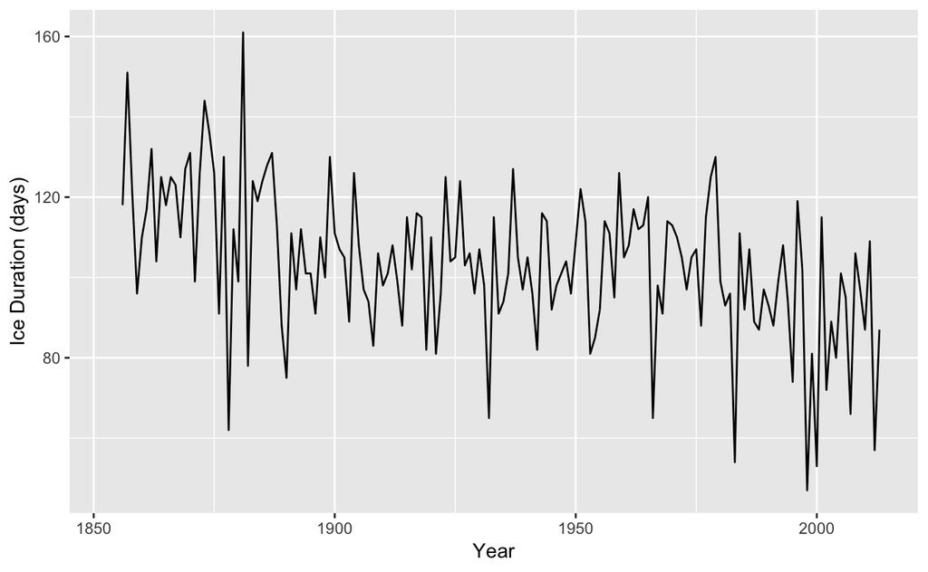

```r
ggplot(lake_ice2, aes(x = iceoff_year, y = duration), na.rm = TRUE)+
  geom_line()+
  labs(x = "Year", y = "Ice Duration (days)")
```

#looks pretty much like the example… moving on.

###Soil Carbon Dioxide

#Library loading

```r
library(tidyverse)
library(lubridate)
```

#Import the data

```r
file_path <- "~/Documents/BI685Files/GitHubDocs/chronister_andrew/data"
soil_co2_raw <- read_tsv(file.path(file_path, "soil_co2.txt"))
soil_co2_raw
```

| DayN[] | Datecode[] | Min[] | Veg[] | Plot[] | Group[] | CorrCO2[] | SoilT[] |
| --- | --- | --- | --- | --- | --- | --- | --- |
| 481 | 1 | 0 | 1 | 6 | 1 | 398.18 | 291.1 |
| 481 | 1 | 15 | 1 | 6 | 1 | 510.06 | 291.1 |
| 481 | 1 | 30 | 1 | 6 | 1 | 499.62 | 291.1 |
| 481 | 1 | 0 | 1 | 18 | 2 | 474.52 | 290.8 |
| 481 | 1 | 15 | 1 | 18 | 2 | 674.17 | 290.8 |
| 481 | 1 | 30 | 1 | 18 | 2 | 763.96 | 290.8 |
| 481 | 1 | 0 | 1 | 14 | 3 | 801.90 | 289.3 |
| 481 | 1 | 15 | 1 | 14 | 3 | 764.36 | 289.3 |
| 481 | 1 | 30 | 1 | 14 | 3 | 830.51 | 289.3 |
| 481 | 1 | 0 | 1 | 10 | 4 | 404.05 | 290.8 |

[output cut: 990 more lines]

#Establish a date variable and rename the columns

```r
ref_date <- "2006-01-01"
soil_co2 <- soil_co2_raw %>%
  rename(Day_number = `DayN[]`,
         Sample_day = `Datecode[]`,
         Minutes = `Min[]`,
         Vegetation = `Veg[]`,
         Plot = `Plot[]`,
         Group = `Group[]`,
         Corrected_CO2_Level = `CorrCO2[]`,
         Soil_temp = `SoilT[]`)
soil_co2
```

| Day_number | Sample_day | Minutes | Vegetation | Plot | Group | Corrected_CO2_Level | Soil_temp |
| --- | --- | --- | --- | --- | --- | --- | --- |
| 481 | 1 | 0 | 1 | 6 | 1 | 398.18 | 291.1 |
| 481 | 1 | 15 | 1 | 6 | 1 | 510.06 | 291.1 |
| 481 | 1 | 30 | 1 | 6 | 1 | 499.62 | 291.1 |
| 481 | 1 | 0 | 1 | 18 | 2 | 474.52 | 290.8 |
| 481 | 1 | 15 | 1 | 18 | 2 | 674.17 | 290.8 |
| 481 | 1 | 30 | 1 | 18 | 2 | 763.96 | 290.8 |
| 481 | 1 | 0 | 1 | 14 | 3 | 801.90 | 289.3 |
| 481 | 1 | 15 | 1 | 14 | 3 | 764.36 | 289.3 |
| 481 | 1 | 30 | 1 | 14 | 3 | 830.51 | 289.3 |
| 481 | 1 | 0 | 1 | 10 | 4 | 404.05 | 290.8 |

[output cut: 990 more lines]

```r
ref_date
```

```
[1] "2006-01-01"
```

#Make date column that tags day number to reference date #Create Year, Month columns and group data by them.

```r
ref_date_int <- ymd(ref_date)
soil_co2 <- soil_co2 %>%
  mutate(
    Date = ref_date_int + Day_number,
    Year = year(Date),
    Month = month(Date, label = TRUE)
  )%>%
  group_by(Year, Month)
soil_co2
```

| Day_number | Sample_day | Minutes | Vegetation | Plot | Group | Corrected_CO2_Level | Soil_temp | Date | Year | Month |
| --- | --- | --- | --- | --- | --- | --- | --- | --- | --- | --- |
| 481 | 1 | 0 | 1 | 6 | 1 | 398.18 | 291.1 | 2007-04-27 | 2007 | Apr |
| 481 | 1 | 15 | 1 | 6 | 1 | 510.06 | 291.1 | 2007-04-27 | 2007 | Apr |
| 481 | 1 | 30 | 1 | 6 | 1 | 499.62 | 291.1 | 2007-04-27 | 2007 | Apr |
| 481 | 1 | 0 | 1 | 18 | 2 | 474.52 | 290.8 | 2007-04-27 | 2007 | Apr |
| 481 | 1 | 15 | 1 | 18 | 2 | 674.17 | 290.8 | 2007-04-27 | 2007 | Apr |
| 481 | 1 | 30 | 1 | 18 | 2 | 763.96 | 290.8 | 2007-04-27 | 2007 | Apr |
| 481 | 1 | 0 | 1 | 14 | 3 | 801.90 | 289.3 | 2007-04-27 | 2007 | Apr |
| 481 | 1 | 15 | 1 | 14 | 3 | 764.36 | 289.3 | 2007-04-27 | 2007 | Apr |
| 481 | 1 | 30 | 1 | 14 | 3 | 830.51 | 289.3 | 2007-04-27 | 2007 | Apr |
| 481 | 1 | 0 | 1 | 10 | 4 | 404.05 | 290.8 | 2007-04-27 | 2007 | Apr |

[output cut: 990 more lines]

#Summarize mean and standard error for CO2

```r
soil_co2_sum <- soil_co2 %>%
  summarize(
    MeanCO2 = mean(Corrected_CO2_Level),
    StdErrCO2 = sd(Corrected_CO2_Level)/sqrt(n())
  )
soil_co2_sum
```

| Year | Month | MeanCO2 | StdErrCO2 |
| --- | --- | --- | --- |
| 2007 | Apr | 610.3469 | 18.16704 |
| 2007 | May | 878.8084 | 16.55794 |
| 2007 | Jun | 1039.9411 | 25.53794 |
| 2007 | Jul | 970.0604 | 31.19578 |
| 2007 | Aug | 1115.6591 | 53.41010 |
| 2007 | Sep | 1004.7191 | 30.35294 |
| 2007 | Oct | 686.1444 | 14.27253 |
| 2008 | Apr | 640.8884 | 12.27243 |
| 2008 | May | 961.0424 | 32.14498 |
| 2008 | Jun | 1151.2460 | 36.37925 |

[output cut: 26 more lines]

```r
NA
```

#Make a column chart of mean CO2

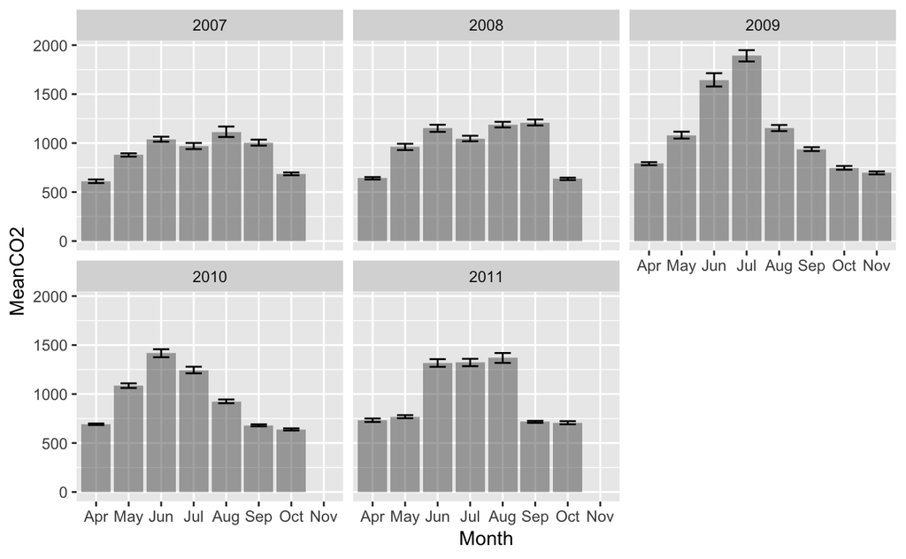

```r
ggplot(soil_co2_sum)+
  geom_col(aes(x = Month, y = MeanCO2), alpha = 1/2)+
  geom_errorbar(aes(x = Month,
                     ymin = MeanCO2 - StdErrCO2,
                     ymax = MeanCO2 + StdErrCO2),
                size = .5, width = .5
                )+
  facet_wrap(~Year, ncol = 3)
```

```r
NA
```

#Make the same plot with points and use linerange.

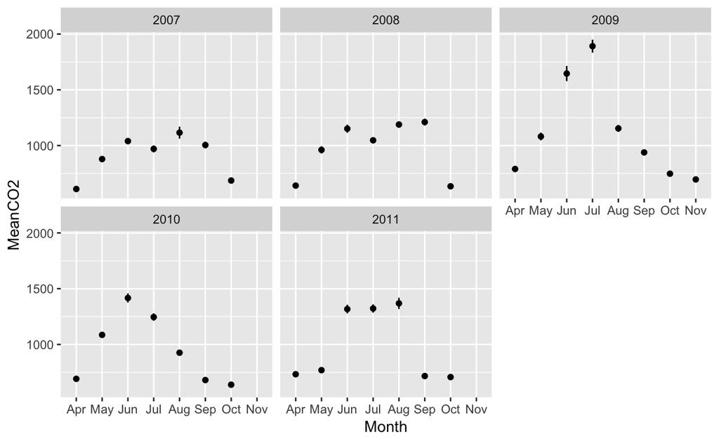

```r
ggplot(soil_co2_sum)+
  geom_point(aes(x = Month, y = MeanCO2))+
  geom_linerange(aes(x = Month,
                     ymin = MeanCO2 - StdErrCO2,
                     ymax = MeanCO2 + StdErrCO2),
                 )+
  facet_wrap(~Year, ncol = 3)
```

###Mississippi River Discharge

#Load the libraries

```r
library(tidyverse)
library(lubridate)
```

#Set the file_path variable and read in the data.

```r
file_path <- "~/Documents/BI685Files/GitHubDocs/chronister_andrew/data"
thebes_raw <- read_csv(file.path(file_path, "thebes_discharge.csv"))
thebes_raw
```

| Month | Day | 1988 | 1989 | 1990 | 1991 | 1992 | 1993 | 1994 | 1995 | 1996 | 1997 | 1998 | 1999 | 2000 | 2001 | 2002 | 2003 | 2004 | 2005 | 2006 | 2007 | 2008 | 2009 | 2010 | 2011 | 2012 | 2013 | 2014 | 2015 | … |
| --- | --- | --- | --- | --- | --- | --- | --- | --- | --- | --- | --- | --- | --- | --- | --- | --- | --- | --- | --- | --- | --- | --- | --- | --- | --- | --- | --- | --- | --- | --- |
| 1 | 1 | 371000 | 134000 | 54500 | 256000 | 205000 | 279000 | 143000 | 135000 | 108000 | 132000 | 160000 | 115000 | 82400 | 77100 | 99600 | 107000 | 133000 | 129000 | 93000 | 161000 | 150000 | 418000 | 436000 | 146000 | 169000 | 68000 | 104000 | 165000 | … |
| 1 | 2 | 329000 | 128000 | 54600 | 254000 | 188000 | 286000 | 149000 | 129000 | 109000 | 140000 | 150000 | 115000 | 86400 | 76200 | 104000 | 109000 | 134000 | 128000 | 92800 | 162000 | 147000 | 408000 | 395000 | 171000 | 166000 | 66900 | 99300 | 156000 | … |
| 1 | 3 | 283000 | 118000 | 54600 | 247000 | 182000 | 286000 | 155000 | 126000 | 109000 | 141000 | 146000 | 119000 | 101000 | 77000 | 101000 | 113000 | 141000 | 128000 | 93400 | 158000 | 137000 | 383000 | 327000 | 205000 | 163000 | 65900 | 99200 | 150000 | … |
| 1 | 4 | 240000 | 115000 | 58600 | 240000 | 175000 | 286000 | 156000 | 119000 | 109000 | 142000 | 144000 | 113000 | 114000 | 77400 | 96200 | 113000 | 142000 | 143000 | 95100 | 155000 | 121000 | 353000 | 265000 | 209000 | 153000 | 65600 | 98400 | 144000 | … |
| 1 | 5 | 211000 | 110000 | 64800 | 217000 | 166000 | 342000 | 154000 | 108000 | 104000 | 142000 | 144000 | 111000 | 113000 | 76700 | 94000 | 108000 | 156000 | 230000 | 99300 | 158000 | 115000 | 327000 | 242000 | 200000 | 146000 | 66700 | 93400 | 141000 | … |
| 1 | 6 | 191000 | 111000 | 66800 | 196000 | 161000 | 435000 | 148000 | 97500 | 99600 | 140000 | 161000 | 112000 | 110000 | 77700 | 94200 | 103000 | 183000 | 425000 | 104000 | 166000 | 123000 | 305000 | 228000 | 202000 | 146000 | 67000 | 91800 | 148000 | … |
| 1 | 7 | 175000 | 125000 | 65800 | 194000 | 155000 | 458000 | 147000 | 91900 | 96700 | 136000 | 194000 | 114000 | 103000 | 79600 | 97700 | 99600 | 193000 | 519000 | 105000 | 172000 | 134000 | 277000 | 232000 | 204000 | 136000 | 66400 | 86800 | 144000 | … |
| 1 | 8 | 167000 | 144000 | 65400 | 184000 | 158000 | 465000 | 154000 | 93500 | 92100 | 136000 | 230000 | 121000 | 102000 | 79600 | 99500 | 97900 | 179000 | 534000 | 103000 | 179000 | 143000 | 253000 | 235000 | 203000 | 129000 | 65700 | 83700 | 131000 | … |
| 1 | 9 | 160000 | 143000 | 67100 | 173000 | 161000 | 456000 | 150000 | 96100 | 90700 | 133000 | 295000 | 120000 | 98600 | 80200 | 98500 | 95000 | 159000 | 500000 | 103000 | 186000 | 160000 | 244000 | 221000 | 199000 | 122000 | 65100 | 82500 | 121000 | … |
| 1 | 10 | 153000 | 123000 | 68200 | 165000 | 163000 | 424000 | 147000 | 96800 | 90300 | 133000 | 345000 | 112000 | 94900 | 80400 | 101000 | 92600 | 144000 | 465000 | 107000 | 187000 | 213000 | 236000 | 211000 | 181000 | 115000 | 65000 | 81400 | 112000 | … |

[output cut: 356 more lines]

#Tidy the data. The data is not tidy right now. Group by year and month

```r
thebes_raw <- na.omit(thebes_raw)
thebes_tidy <- thebes_raw %>%
  gather("1988":"2018", key = "year", value = "discharge") %>%
  mutate(discharge = discharge / 1000)%>%
  group_by(year, Month)
thebes_tidy
```

| Month | Day | year | discharge |
| --- | --- | --- | --- |
| 1 | 1 | 1988 | 371.0 |
| 1 | 2 | 1988 | 329.0 |
| 1 | 3 | 1988 | 283.0 |
| 1 | 4 | 1988 | 240.0 |
| 1 | 5 | 1988 | 211.0 |
| 1 | 6 | 1988 | 191.0 |
| 1 | 7 | 1988 | 175.0 |
| 1 | 8 | 1988 | 167.0 |
| 1 | 9 | 1988 | 160.0 |
| 1 | 10 | 1988 | 153.0 |

[output cut: 990 more lines]

#Summarize the mean discharge.

```r
meandis_sum <- summarize(thebes_tidy,
                           mean_discharge = mean(discharge, na.rm = FALSE))
meandis_sum
```

| year | Month | mean_discharge |
| --- | --- | --- |
| 1988 | 1 | 189.38710 |
| 1988 | 2 | 211.21429 |
| 1988 | 3 | 211.19355 |
| 1988 | 4 | 266.76667 |
| 1988 | 5 | 140.06452 |
| 1988 | 6 | 83.85667 |
| 1988 | 7 | 73.60000 |
| 1988 | 8 | 71.63871 |
| 1988 | 9 | 75.86000 |
| 1988 | 10 | 77.20000 |

[output cut: 362 more lines]

#Add event column

```r
meandis_sum <- mutate(meandis_sum,
                      event = case_when(
                        year == "1993" ~ "Flood",
                        year == "2011" ~ "Flood",
                        year == "1988" ~ "Drought",
                        year == "2012" ~ "Drought",
                        TRUE ~"Normal"
                      ))
meandis_sum
```

| year | Month | mean_discharge | event |
| --- | --- | --- | --- |
| 1988 | 1 | 189.38710 | Drought |
| 1988 | 2 | 211.21429 | Drought |
| 1988 | 3 | 211.19355 | Drought |
| 1988 | 4 | 266.76667 | Drought |
| 1988 | 5 | 140.06452 | Drought |
| 1988 | 6 | 83.85667 | Drought |
| 1988 | 7 | 73.60000 | Drought |
| 1988 | 8 | 71.63871 | Drought |
| 1988 | 9 | 75.86000 | Drought |
| 1988 | 10 | 77.20000 | Drought |

[output cut: 362 more lines]

#Make a second data set

```r
special_years <- meandis_sum%>%
  filter(event %in% c("Flood", "Drought"))
special_years
```

| year | Month | mean_discharge | event |
| --- | --- | --- | --- |
| 1988 | 1 | 189.38710 | Drought |
| 1988 | 2 | 211.21429 | Drought |
| 1988 | 3 | 211.19355 | Drought |
| 1988 | 4 | 266.76667 | Drought |
| 1988 | 5 | 140.06452 | Drought |
| 1988 | 6 | 83.85667 | Drought |
| 1988 | 7 | 73.60000 | Drought |
| 1988 | 8 | 71.63871 | Drought |
| 1988 | 9 | 75.86000 | Drought |
| 1988 | 10 | 77.20000 | Drought |

[output cut: 38 more lines]

#Plot the data

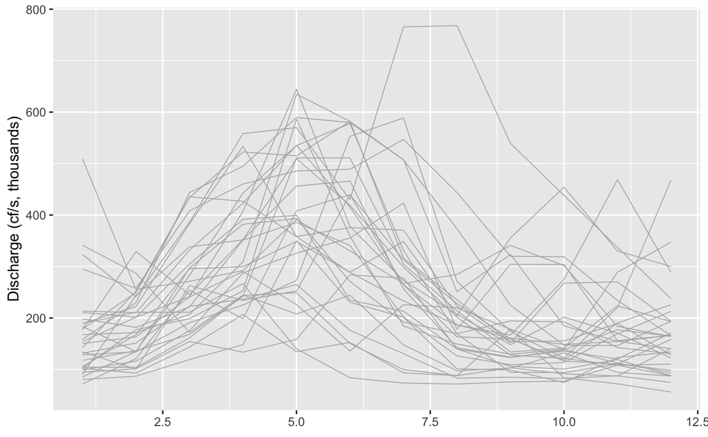

```r
dis_plot <- ggplot()+
  geom_line(meandis_sum, mapping = aes(x = Month, y = mean_discharge, group = year),
            size = 0.3,
            color = "gray70")+
  labs(x = NULL, y = "Discharge (cf/s, thousands)")
dis_plot
```

#Add smaller data set

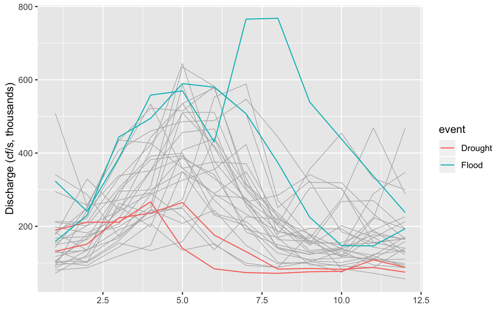

```r
special_years %>%
  ggplot() +
  geom_line(meandis_sum, mapping = aes(x = Month, y = mean_discharge, group = year),
            size = 0.3,
            color = "gray70")+
  labs(x = NULL, y = "Discharge (cf/s, thousands)")+
  geom_line(data = special_years, aes(x = Month, y = mean_discharge, group = year, color = event))
```

```r
NA
NA
```